```r
library(tseries)
library(forecast)
library(TSA)
library(fpp)
library(readxl)
library(dplyr)
```

```r
library(ggplot2)
library(stats)
library(sae)
tourist_arrival <- read_excel("arrival.xlsx")
head(tourist_arrival)
```

```
## # A tibble: 6 × 7
##   date                arrival   oil geopol globcci  sars   gfc
##   <dttm>                <dbl> <dbl>  <dbl>   <dbl> <dbl> <dbl>
## 1 2000-01-01 00:00:00  356090  25.5 0.0959    80       0     0
## 2 2000-02-01 00:00:00  397548  27.8 0.0637    80.2     0     0
## 3 2000-03-01 00:00:00  413502  27.5 0.0328    80.4     0     0
## 4 2000-04-01 00:00:00  408239  22.8 0.0360    80.7     0     0
## 5 2000-05-01 00:00:00  370474  27.7 0.0483    80.9     0     0
## 6 2000-06-01 00:00:00  424277  29.8 0.0286    81       0     0
```

Plot the data

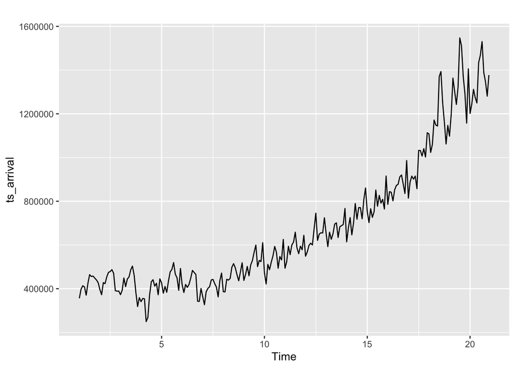

```r
ts_arrival <- ts(tourist_arrival$arrival, frequency=12)
autoplot(ts_arrival)
```

Train and test split

```r
tourist_arrival$date <- as.Date(tourist_arrival$date)

train_data <- subset(tourist_arrival, date >= as.Date("2000-01-01") & date <= as.Date("2015-12-01"))
test_data <- subset(tourist_arrival, date >= as.Date("2016-01-01") & date <= as.Date("2019-12-01"))

head(train_data)
```

```
## # A tibble: 6 × 7
##   date       arrival   oil geopol globcci  sars   gfc
##   <date>       <dbl> <dbl>  <dbl>   <dbl> <dbl> <dbl>
## 1 2000-01-01  356090  25.5 0.0959    80       0     0
## 2 2000-02-01  397548  27.8 0.0637    80.2     0     0
## 3 2000-03-01  413502  27.5 0.0328    80.4     0     0
## 4 2000-04-01  408239  22.8 0.0360    80.7     0     0
## 5 2000-05-01  370474  27.7 0.0483    80.9     0     0
## 6 2000-06-01  424277  29.8 0.0286    81       0     0
```

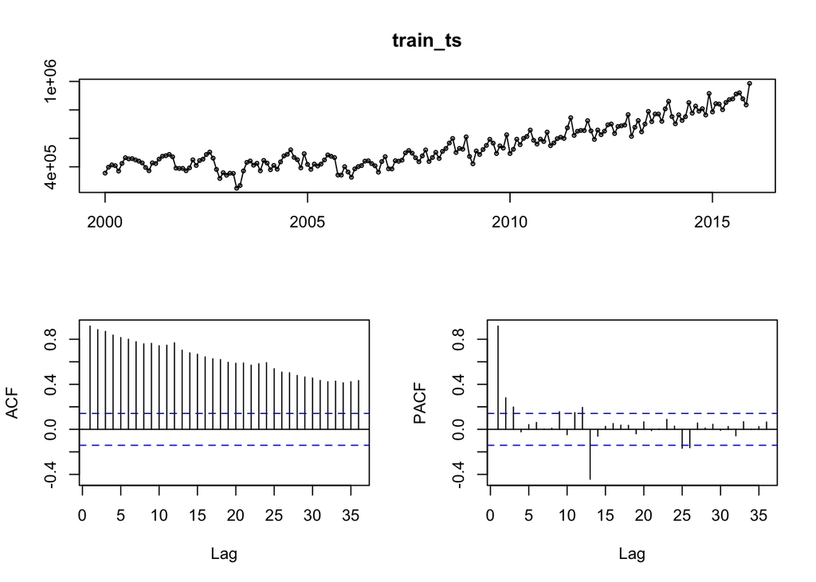

```r
# Extracting the year and month for the start argument
start_train <- as.numeric(format(train_data$date[1], "%Y"))
start_test <- as.numeric(format(test_data$date[1], "%Y"))

# Create time series for training and testing
train_ts <- ts(train_data$arrival, frequency = 12, start = c(start_train, 1))
test_ts <- ts(test_data$arrival, frequency = 12, start = c(start_test, 1))

# Display the time series
tsdisplay(train_ts)
```

```r
ndiffs(train_ts)
```

```
## [1] 1
```

```r
nsdiffs(train_ts)
```

```
## [1] 1
```

##MODEL TRAINING 1. SARIMA model 1 with auto.arima function

```r
sarima_model_1 <- auto.arima(train_ts, trace=TRUE, seasonal=TRUE, lambda="auto")
```

```
##
##  Fitting models using approximations to speed things up...
##
##  ARIMA(2,1,2)(1,1,1)[12]                    : 2977.333
##  ARIMA(0,1,0)(0,1,0)[12]                    : 3037.057
##  ARIMA(1,1,0)(1,1,0)[12]                    : 2997.369
##  ARIMA(0,1,1)(0,1,1)[12]                    : 2970.969
##  ARIMA(0,1,1)(0,1,0)[12]                    : 3007.088
##  ARIMA(0,1,1)(1,1,1)[12]                    : 2970.631
##  ARIMA(0,1,1)(1,1,0)[12]                    : 2987.939
##  ARIMA(0,1,1)(2,1,1)[12]                    : 2977.301
##  ARIMA(0,1,1)(1,1,2)[12]                    : 2967.496
##  ARIMA(0,1,1)(0,1,2)[12]                    : 2967.552
##  ARIMA(0,1,1)(2,1,2)[12]                    : 2978.737
##  ARIMA(0,1,0)(1,1,2)[12]                    : 3002.114
##  ARIMA(1,1,1)(1,1,2)[12]                    : 2971.146
##  ARIMA(0,1,2)(1,1,2)[12]                    : 2968.711
##  ARIMA(1,1,0)(1,1,2)[12]                    : 2980.698
##  ARIMA(1,1,2)(1,1,2)[12]                    : 2973.069
##
##  Now re-fitting the best model(s) without approximations...
##
##  ARIMA(0,1,1)(1,1,2)[12]                    : 3165.848
##
##  Best model: ARIMA(0,1,1)(1,1,2)[12]
```

```r
summary(sarima_model_1)
```

```
## Series: train_ts
## ARIMA(0,1,1)(1,1,2)[12]
## Box Cox transformation: lambda= 0.7649068
##
## Coefficients:
##           ma1     sar1     sma1     sma2
##       -0.5319  -0.3583  -0.1989  -0.4300
## s.e.   0.0746   0.4719   0.4564   0.2753
##
## sigma^2 = 2581587:  log likelihood = -1577.75
## AIC=3165.5   AICc=3165.85   BIC=3181.44
##
## Training set error measures:
##                    ME     RMSE      MAE         MPE     MAPE      MASE
## Training set 1722.666 33751.14 25730.21 -0.03409346 5.059827 0.4971804
##                     ACF1
## Training set 0.008725321
```

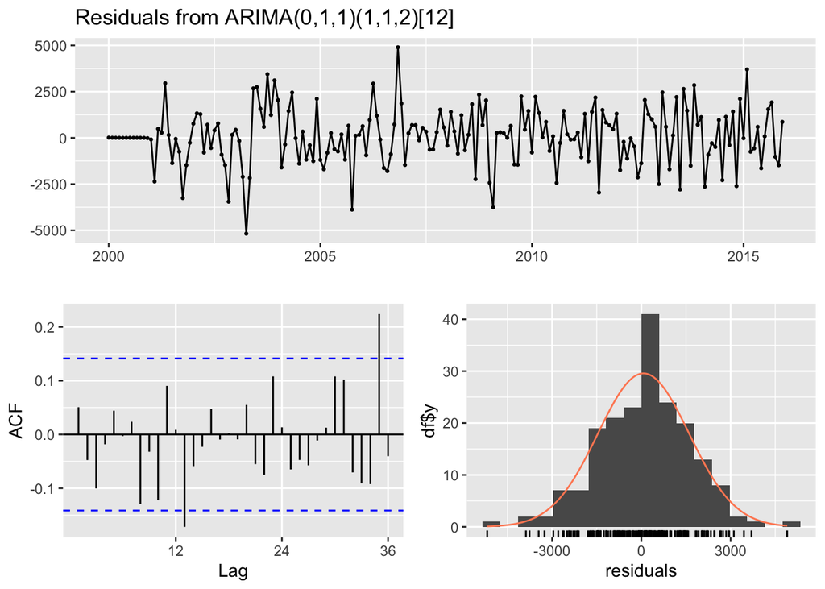

```
##
##  Ljung-Box test
##
## data:  Residuals from ARIMA(0,1,1)(1,1,2)[12]
## Q* = 24.458, df = 20, p-value = 0.223
##
## Model df: 4.   Total lags used: 24
```

```r
checkresiduals(sarima_model_1)
```

p-value greater than 0.05 means there is no autocorrelation in the residuals of the SARIMA model. This indicate that the SARIMA model ARIMA(0,1,1)(1,1,2)[12] has adequately captured the pattern existing in the data.

```r
sarima_model_3 <- auto.arima(train_ts, trace=TRUE, seasonal=TRUE, lambda=0)
```

```
##
##  Fitting models using approximations to speed things up...
##
##  ARIMA(2,1,2)(1,1,1)[12]                    : -335.6835
##  ARIMA(0,1,0)(0,1,0)[12]                    : -286.0944
##  ARIMA(1,1,0)(1,1,0)[12]                    : -310.3127
##  ARIMA(0,1,1)(0,1,1)[12]                    : -333.3479
##  ARIMA(2,1,2)(0,1,1)[12]                    : -340.7191
##  ARIMA(2,1,2)(0,1,0)[12]                    : Inf
##  ARIMA(2,1,2)(0,1,2)[12]                    : -348.1345
##  ARIMA(2,1,2)(1,1,2)[12]                    : -341.5567
##  ARIMA(1,1,2)(0,1,2)[12]                    : -345.2702
##  ARIMA(2,1,1)(0,1,2)[12]                    : -344.6548
##  ARIMA(3,1,2)(0,1,2)[12]                    : -342.625
##  ARIMA(2,1,3)(0,1,2)[12]                    : -347.1879
##  ARIMA(1,1,1)(0,1,2)[12]                    : -340.3513
##  ARIMA(1,1,3)(0,1,2)[12]                    : -347.2399
##  ARIMA(3,1,1)(0,1,2)[12]                    : -344.4192
##  ARIMA(3,1,3)(0,1,2)[12]                    : -343.1081
##
##  Now re-fitting the best model(s) without approximations...
##
##  ARIMA(2,1,2)(0,1,2)[12]                    : Inf
##  ARIMA(1,1,3)(0,1,2)[12]                    : Inf
##  ARIMA(2,1,3)(0,1,2)[12]                    : Inf
##  ARIMA(1,1,2)(0,1,2)[12]                    : Inf
##  ARIMA(2,1,1)(0,1,2)[12]                    : Inf
##  ARIMA(3,1,1)(0,1,2)[12]                    : Inf
##  ARIMA(3,1,3)(0,1,2)[12]                    : Inf
##  ARIMA(3,1,2)(0,1,2)[12]                    : Inf
##  ARIMA(2,1,2)(1,1,2)[12]                    : -406.6427
##
##  Best model: ARIMA(2,1,2)(1,1,2)[12]
```

```r
summary(sarima_model_3)
```

```
## Series: train_ts
## ARIMA(2,1,2)(1,1,2)[12]
## Box Cox transformation: lambda= 0
##
## Coefficients:
##          ar1      ar2      ma1     ma2     sar1     sma1     sma2
##       1.2111  -0.3122  -1.5520  0.5754  -0.0487  -0.5429  -0.3018
## s.e.  0.2784   0.1970   0.2582  0.2377   0.6484   0.6770   0.4487
##
## sigma^2 = 0.005271:  log likelihood = 211.74
## AIC=-407.49   AICc=-406.64   BIC=-381.99
##
## Training set error measures:
##                    ME     RMSE      MAE       MPE   MAPE      MASE       ACF1
## Training set 3521.653 34227.25 26071.88 0.3061986 5.0312 0.5037824 -0.1351338
```

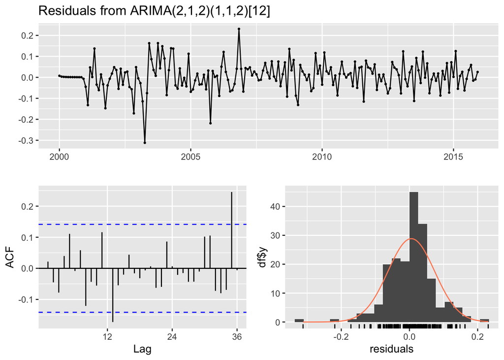

```
##
##  Ljung-Box test
##
## data:  Residuals from ARIMA(2,1,2)(1,1,2)[12]
## Q* = 22.783, df = 17, p-value = 0.1564
##
## Model df: 7.   Total lags used: 24
```

```r
checkresiduals(sarima_model_3)
```

2. SARIMA model 2 from model identification from ACF and PACF plots.

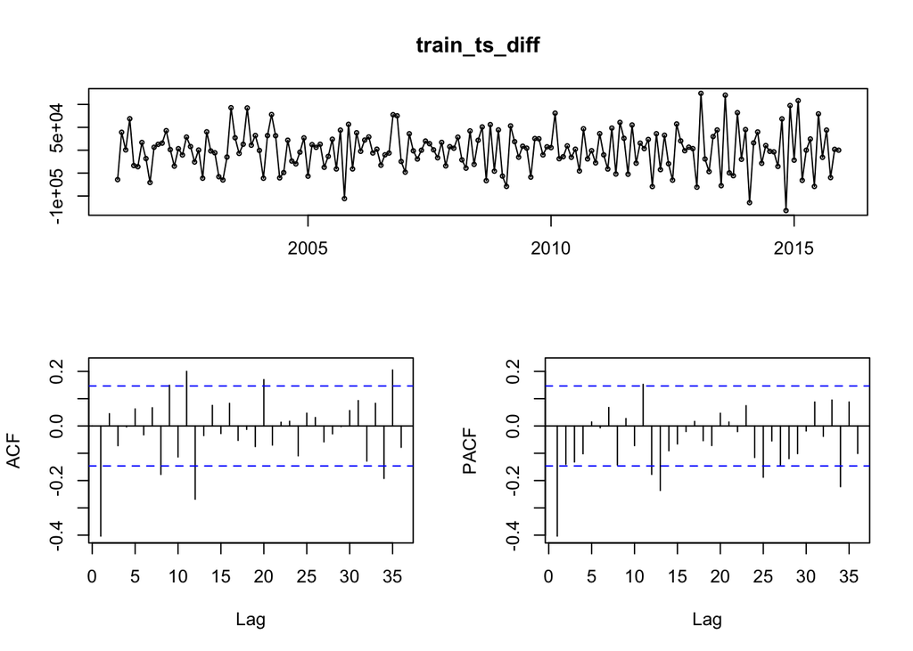

```r
#Plot ACF and PACF for differenced data (regular and seasonally differencing) to remove trend and seasonality
train_ts_diff <- diff(diff(train_ts), lag = 12)
tsdisplay(train_ts_diff)
```

```r
#SARIMA(1,1,0)(1,1,1)[12]
#Apply box cox transformation first
transformed_data <- BoxCox(train_ts, lambda=0.7649068)
sarima_model_2 <- Arima(transformed_data, order = c(1, 1, 0),
                          seasonal = list(order = c(1, 1, 1), period = 12))
summary(sarima_model_2)
```

```
## Series: transformed_data
## ARIMA(1,1,0)(1,1,1)[12]
##
## Coefficients:
##           ar1    sar1     sma1
##       -0.3581  0.3740  -0.9242
## s.e.   0.0704  0.1213   0.1543
##
## sigma^2 = 2641123:  log likelihood = -1582.9
## AIC=3173.8   AICc=3174.03   BIC=3186.55
##
## Training set error measures:
##                    ME     RMSE      MAE         MPE     MAPE      MASE
## Training set 45.67188 1555.966 1182.677 -0.02961303 3.922409 0.5052914
##                     ACF1
## Training set -0.04965103
```

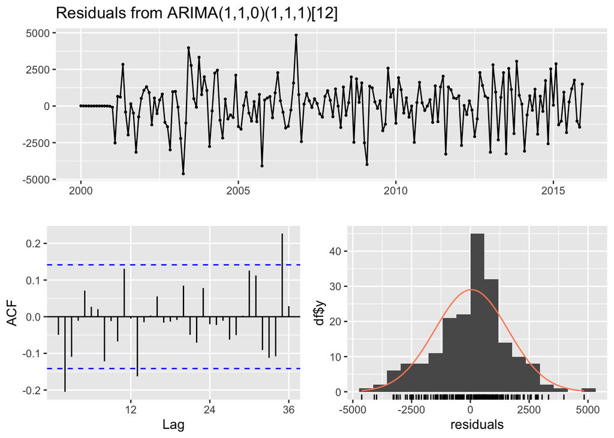

```
##
##  Ljung-Box test
##
## data:  Residuals from ARIMA(1,1,0)(1,1,1)[12]
## Q* = 30.758, df = 21, p-value = 0.07778
##
## Model df: 3.   Total lags used: 24
```

```r
checkresiduals(sarima_model_2)
```

p-value greater than 0.05 means there is no significant autocorrelation in the residuals of the SARIMA model. This indicate that the SARIMA model ARIMA(1,1,0)(1,1,1)[12] has adequately captured the pattern existing in the data.

```r
#SARIMA(1,1,0)(1,1,1)[12]
#Apply box cox transformation first
transformed_data_2 <- BoxCox(train_ts, lambda=0)
sarima_model_4 <- Arima(transformed_data_2, order = c(1, 1, 0),
                          seasonal = list(order = c(1, 1, 1), period = 12))
summary(sarima_model_4)
```

```
## Series: transformed_data_2
## ARIMA(1,1,0)(1,1,1)[12]
##
## Coefficients:
##           ar1    sar1     sma1
##       -0.2169  0.3405  -1.0000
## s.e.   0.0736  0.0779   0.1345
##
## sigma^2 = 0.005289:  log likelihood = 204.15
## AIC=-400.29   AICc=-400.06   BIC=-387.54
##
## Training set error measures:
##                        ME       RMSE       MAE         MPE      MAPE      MASE
## Training set 0.0008313131 0.06963145 0.0505669 0.004880079 0.3858183 0.4958839
##                     ACF1
## Training set -0.02068285
```

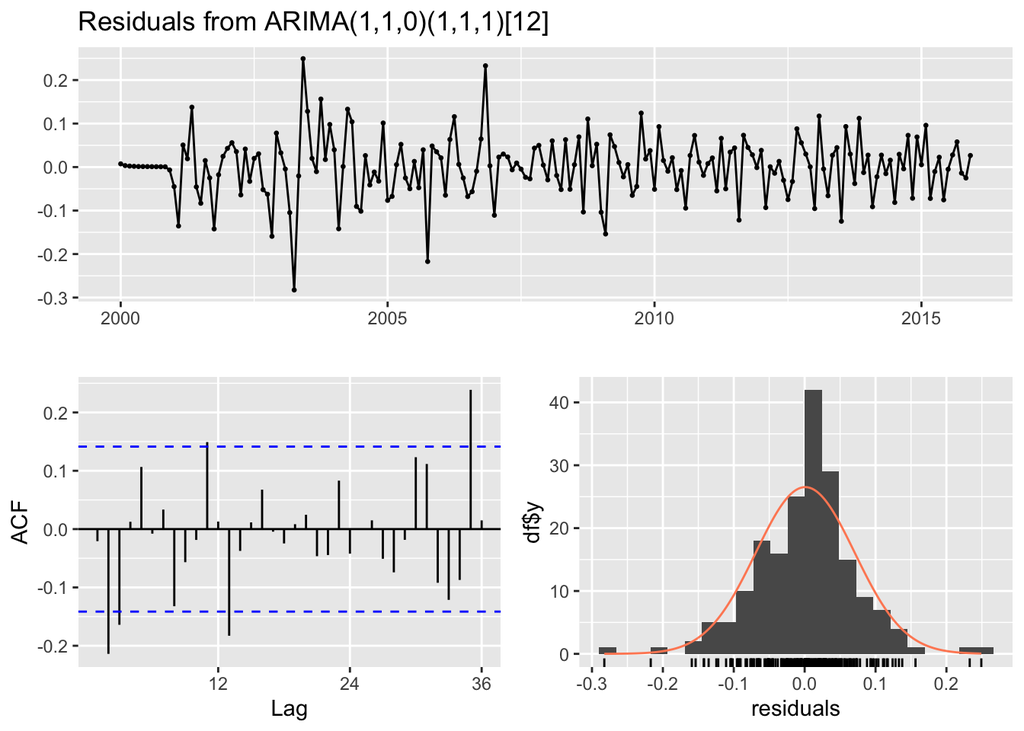

```
##
##  Ljung-Box test
##
## data:  Residuals from ARIMA(1,1,0)(1,1,1)[12]
## Q* = 37.106, df = 21, p-value = 0.01637
##
## Model df: 3.   Total lags used: 24
```

```r
checkresiduals(sarima_model_4)
```

*Forecast* 1. Forecast sarima model 1

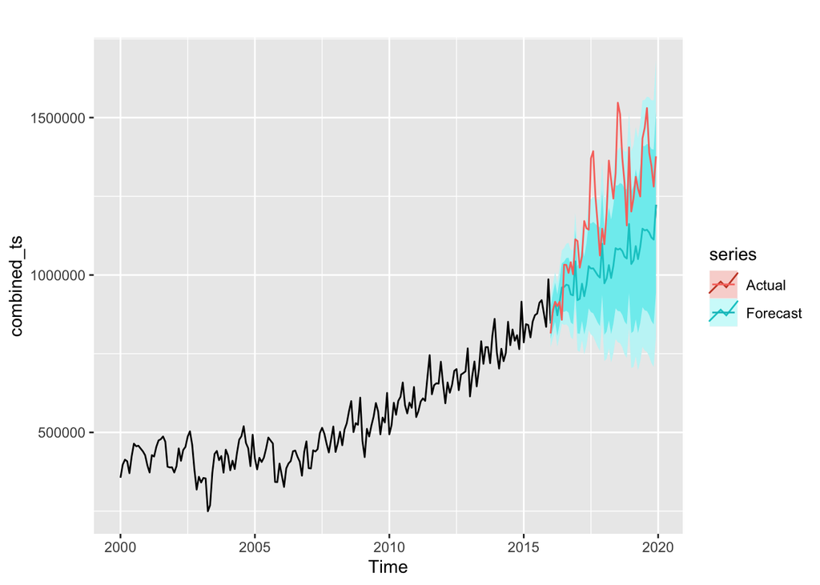

```r
forecast_sarima_1 <- forecast(sarima_model_1, h=48)

# Combine forecast and test data
combined_data <- c(as.vector(train_ts), as.vector(forecast_sarima_1$mean))

# Create a time series for combined data with appropriate dates
combined_dates <- seq(as.Date("2000-01-01"), length.out = length(combined_data), by = "months")
combined_ts <- ts(combined_data, frequency = 12, start = c(as.POSIXlt(combined_dates[1])$year + 1900, as.POSIXlt(combined_dates[1])$mon + 1))

# Plot
autoplot(combined_ts) +
  autolayer(forecast_sarima_1, series = "Forecast") +
  autolayer(test_ts, series = "Actual")
```

```r
accuracy(forecast_sarima_1, test_data$arrival)
```

```
##                      ME      RMSE       MAE         MPE      MAPE      MASE
## Training set   1722.666  33751.14  25730.21 -0.03409346  5.059827 0.6037689
## Test set     175712.147 215449.37 181397.44 13.44564190 14.117298 4.2565577
##                     ACF1
## Training set 0.008725321
## Test set              NA
```

```r
mse <- mean(forecast_sarima_1$residuals^2)
print(mse)
```

```
## [1] 2353009
```

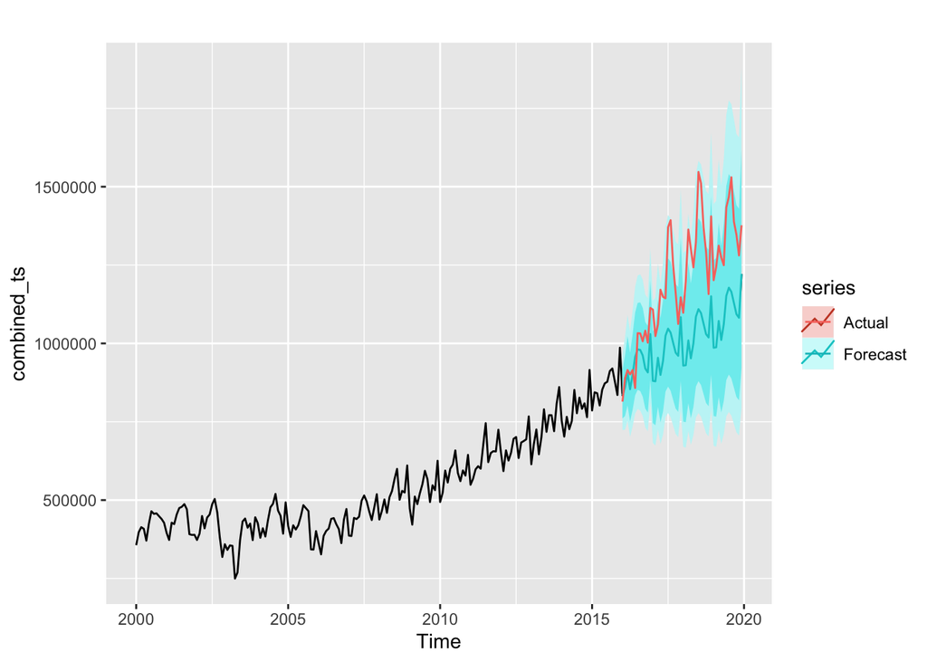

```r
forecast_sarima_3 <- forecast(sarima_model_3, h=48)

# Combine forecast and test data
combined_data <- c(as.vector(train_ts), as.vector(forecast_sarima_3$mean))

# Create a time series for combined data with appropriate dates
combined_dates <- seq(as.Date("2000-01-01"), length.out = length(combined_data), by = "months")
combined_ts <- ts(combined_data, frequency = 12, start = c(as.POSIXlt(combined_dates[1])$year + 1900, as.POSIXlt(combined_dates[1])$mon + 1))

# Plot
autoplot(combined_ts) +
  autolayer(forecast_sarima_3, series = "Forecast") +
  autolayer(test_ts, series = "Actual")
```

```r
accuracy(forecast_sarima_3, test_data$arrival)
```

```
##                      ME      RMSE       MAE        MPE     MAPE      MASE
## Training set   3521.653  34227.25  26071.88  0.3061986  5.03120 0.6117863
## Test set     191522.301 226040.08 196527.01 14.8705284 15.45934 4.6115787
##                    ACF1
## Training set -0.1351338
## Test set             NA
```

2. Forecast sarima model 2

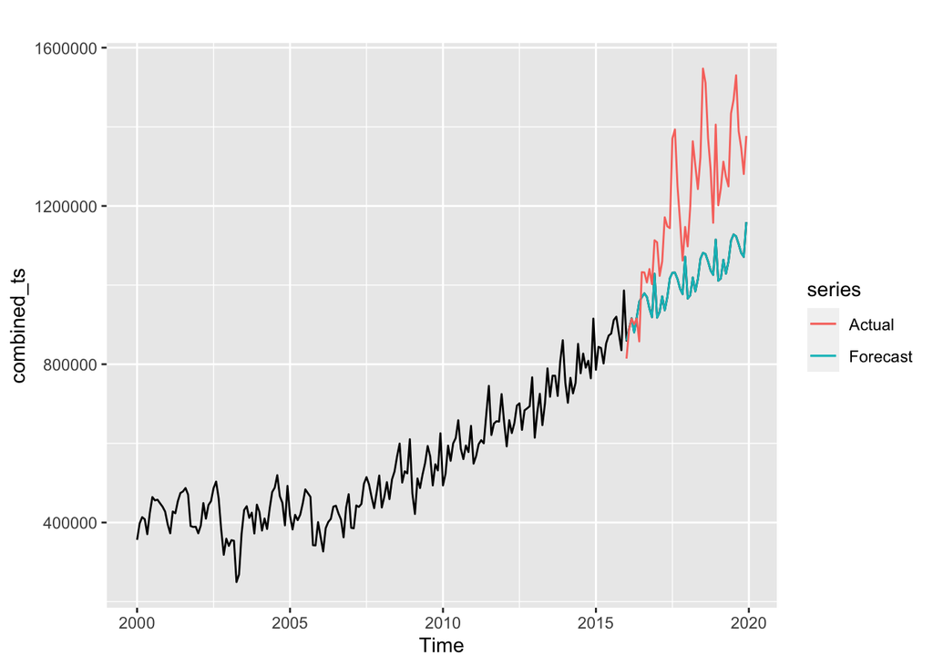

```r
forecast_sarima_2 <- forecast(sarima_model_2, h=48)

lambda <- 0.7649068
forecast_inv <- bxcx(forecast_sarima_2$mean, lambda=lambda, InverseQ=TRUE)

# Combine forecast and test data
combined_data <- c(as.vector(train_ts), as.vector(forecast_inv))

# Create a time series for combined data with appropriate dates
combined_dates <- seq(as.Date("2000-01-01"), length.out = length(combined_data), by = "months")
combined_ts <- ts(combined_data, frequency = 12, start = c(as.POSIXlt(combined_dates[1])$year + 1900, as.POSIXlt(combined_dates[1])$mon + 1))

# Plot
autoplot(combined_ts) +
  autolayer(forecast_inv, series = "Forecast") +
  autolayer(test_ts, series = "Actual")
```

```r
#TEST SET
accuracy(forecast_inv, test_data$arrival)
```

```
##                ME     RMSE      MAE      MPE     MAPE
## Test set 187563.3 227718.7 193861.4 14.33433 15.07898
```

```r
#TRAIN SET
inv_fitted <- bxcx(sarima_model_2$fitted, lambda=lambda, InverseQ=TRUE)
accuracy(inv_fitted, train_data$arrival)
```

```
##                ME     RMSE      MAE         MPE     MAPE
## Test set 1085.461 34353.77 26236.19 -0.09900518 5.136494
```

Forecast sarima model 4

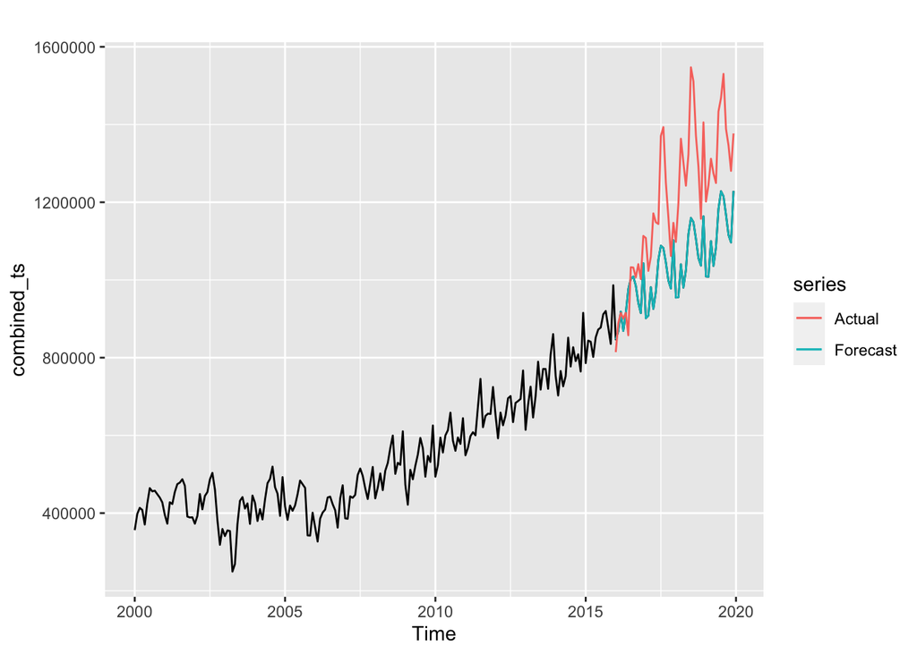

```r
forecast_sarima_4 <- forecast(sarima_model_4, h=48)

lambda <- 0
forecast_inv <- bxcx(forecast_sarima_4$mean, lambda=lambda, InverseQ=TRUE)

# Combine forecast and test data
combined_data <- c(as.vector(train_ts), as.vector(forecast_inv))

# Create a time series for combined data with appropriate dates
combined_dates <- seq(as.Date("2000-01-01"), length.out = length(combined_data), by = "months")
combined_ts <- ts(combined_data, frequency = 12, start = c(as.POSIXlt(combined_dates[1])$year + 1900, as.POSIXlt(combined_dates[1])$mon + 1))

# Plot
autoplot(combined_ts) +
  autolayer(forecast_inv, series = "Forecast") +
  autolayer(test_ts, series = "Actual")
```

```r
accuracy(forecast_inv, test_data$arrival)
```

```
##                ME     RMSE      MAE     MPE     MAPE
## Test set 165376.8 199693.2 171833.7 12.7368 13.49702
```